# RT-qPCR 2022-10-14 GAT201 targets

Liz Hughes

07/10/2022

# Experimental Design

This experiment was set up to examine the expression of Gat201 in different strains of **Cryptococcus neoformans** grown under the same conditions.

Strains: H99, KN99-alpha (KNa), Madhani-Gat201 deletion mutant (gat20l∆m) and 2 Gat201 complemented strains (into Madhani-Gat201 deletion strain) C26 (GAT201-C1) and C30 (GAT201-C2).

Sample collection: 19 ml Samples were collected at 6 hours. Samples were fixed in methanol on dry ice for 3-5 mins. My Cryptococcus RNA extraction protocol was followed to isolate RNA from samples.The samples were NOT lyophilise due to timr constraints.

Replicates: - 3 biological replicates were collected for each sample. - 3 technical replicates +RT and 1 -RT

Reference gene primers: - SRP14 CNAG_04994 - ACT1 CNAG_00483 - GPD1 CNAG_00121

```r
library(tidyverse)
library(tidyqpcr)
library(cowplot)
library(extrafont)
theme_set(
  theme_cowplot(font_size = 12, font_family = "Arial",
                rel_large = 1) +
    theme(strip.background = element_blank(),
          panel.border =
            element_rect(color = "grey90",
                         fill = NA,
                         linetype = 1,
                         size = 1),
          panel.grid.major.y =
            element_line(size = 0.5,
                         colour = "grey90"))
)
```

# Describe the experimental design in a plate plan

## Columns are target_ids of primer sets

```r
colkey <- create_colkey_6_in_24(
  target_id = c("GAT201", "GAT204", "LIV3", "SRP14", "ACT1", "GPD1") %>%
    as_factor()
)

print(colkey)
```

```
## # A tibble: 24 × 4
##    well_col prep_type tech_rep target_id
##    <fct>    <fct>     <fct>    <fct>
##  1 1        +RT       1        GAT201
##  2 2        +RT       1        GAT204
##  3 3        +RT       1        LIV3
##  4 4        +RT       1        SRP14
##  5 5        +RT       1        ACT1
##  6 6        +RT       1        GPD1
##  7 7        +RT       2        GAT201
##  8 8        +RT       2        GAT204
##  9 9        +RT       2        LIV3
## 10 10       +RT       2        SRP14
## # … with 14 more rows
```

## Rows are sample name, Strain, BioRep (3) and TechRep (3)

Also choose colours to display strains.

```r
strain_df <- tibble( Strain = c("H99", "KN99alpha", "deltaGat201", "C26", "C30" ),
                     Strain_nice = c("H99", "GAT201", "gat201∆m", "GAT201-C1", "GAT201-C2"),
                     colour = c("khaki4", "grey20",  "darkred", "blue3", "cyan4"))

scale_color_strain <-
  scale_color_manual("Strain",
                     breaks = strain_df$Strain_nice,
                     values = strain_df$colour)

rowkey <- tibble(well_row = LETTERS[1:15],
                 Strain = strain_df$Strain %>%
                   rep(each = 3) %>%
                   as_factor(),
                 Strain_nice = strain_df$Strain_nice %>%
                   rep(each = 3) %>%
                   as_factor(),
                 BioRep = 1:3 %>%
                   as_factor() %>%
                   rep(times = 5)) %>%
  unite(sample_id, Strain, BioRep, remove = FALSE) %>%
  mutate(sample_id = as_factor(sample_id))

print(rowkey)
```

```
## # A tibble: 15 × 5
##    well_row sample_id     Strain      Strain_nice BioRep
##    <chr>    <fct>         <fct>       <fct>       <fct>
##  1 A        H99_1         H99         H99         1
##  2 B        H99_2         H99         H99         2
##  3 C        H99_3         H99         H99         3
##  4 D        KN99alpha_1   KN99alpha   GAT201      1
##  5 E        KN99alpha_2   KN99alpha   GAT201      2
##  6 F        KN99alpha_3   KN99alpha   GAT201      3
##  7 G        deltaGat201_1 deltaGat201 gat201∆m    1
##  8 H        deltaGat201_2 deltaGat201 gat201∆m    2
##  9 I        deltaGat201_3 deltaGat201 gat201∆m    3
## 10 J        C26_1         C26         GAT201-C1   1
## 11 K        C26_2         C26         GAT201-C1   2
## 12 L        C26_3         C26         GAT201-C1   3
## 13 M        C30_1         C30         GAT201-C2   1
## 14 N        C30_2         C30         GAT201-C2   2
## 15 O        C30_3         C30         GAT201-C2   3
```

## Combine into plate plan

```r
plate_plan <- label_plate_rowcol(
  plate = create_blank_plate(well_row = LETTERS[1:15], well_col = 1:24),
  rowkey = rowkey,
  colkey = colkey
)

print(plate_plan)
```

```
## # A tibble: 360 × 10
##    well  well_row well_col prep_type tech_rep target_id sample_id Strain
##    <chr> <fct>    <fct>    <fct>     <fct>    <fct>     <fct>     <fct>
##  1 A1    A        1        +RT       1        GAT201    H99_1     H99
##  2 A2    A        2        +RT       1        GAT204    H99_1     H99
##  3 A3    A        3        +RT       1        LIV3      H99_1     H99
##  4 A4    A        4        +RT       1        SRP14     H99_1     H99
##  5 A5    A        5        +RT       1        ACT1      H99_1     H99
##  6 A6    A        6        +RT       1        GPD1      H99_1     H99
##  7 A7    A        7        +RT       2        GAT201    H99_1     H99
##  8 A8    A        8        +RT       2        GAT204    H99_1     H99
##  9 A9    A        9        +RT       2        LIV3      H99_1     H99
## 10 A10   A        10       +RT       2        SRP14     H99_1     H99
## # … with 350 more rows, and 2 more variables: Strain_nice <fct>, BioRep <fct>
```

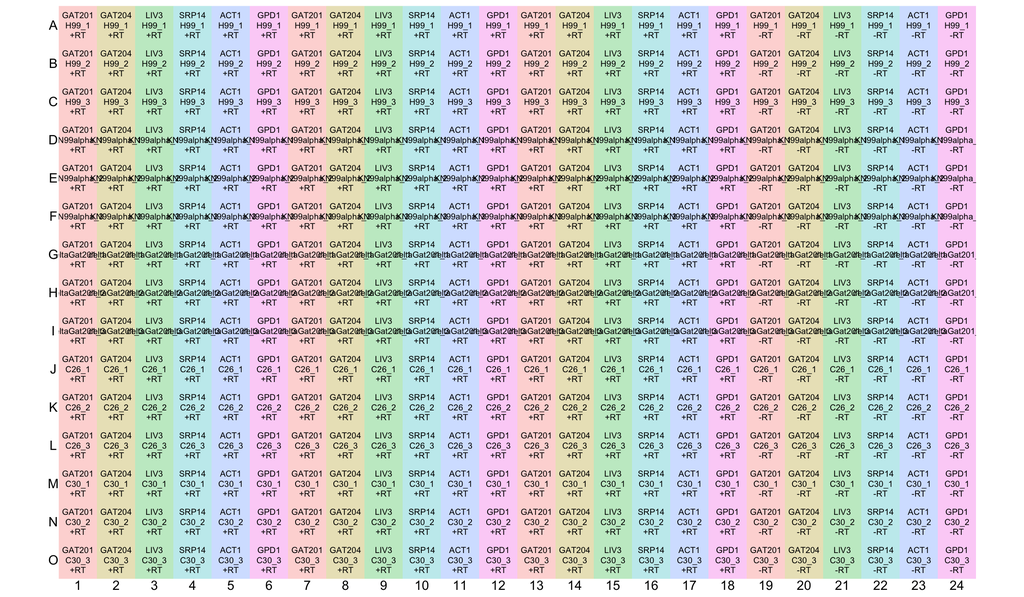

```r
display_plate_qpcr(plate_plan)
```

# Load data of RT-qPCR results in Cq format

```r
plate <- read_tsv( "../Input/20221014_ComplementCheck_EH_Ct.txt",
                    skip=1) %>%
    mutate(well=Pos,cq=Cp) %>%
    right_join(plate_plan)

plate
```

```
## # A tibble: 360 × 19
##    Include Color Pos   Name         Cp Concentration Standard Status well     cq
##    <lgl>   <dbl> <chr> <chr>     <dbl> <lgl>            <dbl> <lgl>  <chr> <dbl>
##  1 TRUE      255 A1    Sample 1   18.7 NA                   0 NA     A1     18.7
##  2 TRUE      255 A2    Sample 2   21.6 NA                   0 NA     A2     21.6
##  3 TRUE      255 A3    Sample 3   19.9 NA                   0 NA     A3     19.9
##  4 TRUE      255 A4    Sample 4   23.4 NA                   0 NA     A4     23.4
##  5 TRUE      255 A5    Sample 5   17.4 NA                   0 NA     A5     17.4
##  6 TRUE      255 A6    Sample 6   22.6 NA                   0 NA     A6     22.6
##  7 TRUE      255 A7    Sample 7   18.3 NA                   0 NA     A7     18.3
##  8 TRUE      255 A8    Sample 8   21.7 NA                   0 NA     A8     21.7
##  9 TRUE      255 A9    Sample 9   20.3 NA                   0 NA     A9     20.3
## 10 TRUE      255 A10   Sample 10  23.4 NA                   0 NA     A10    23.4
## # … with 350 more rows, and 9 more variables: well_row <fct>, well_col <fct>,
## #   prep_type <fct>, tech_rep <fct>, target_id <fct>, sample_id <fct>,
## #   Strain <fct>, Strain_nice <fct>, BioRep <fct>
```

# Plot all replicates, unnormalized

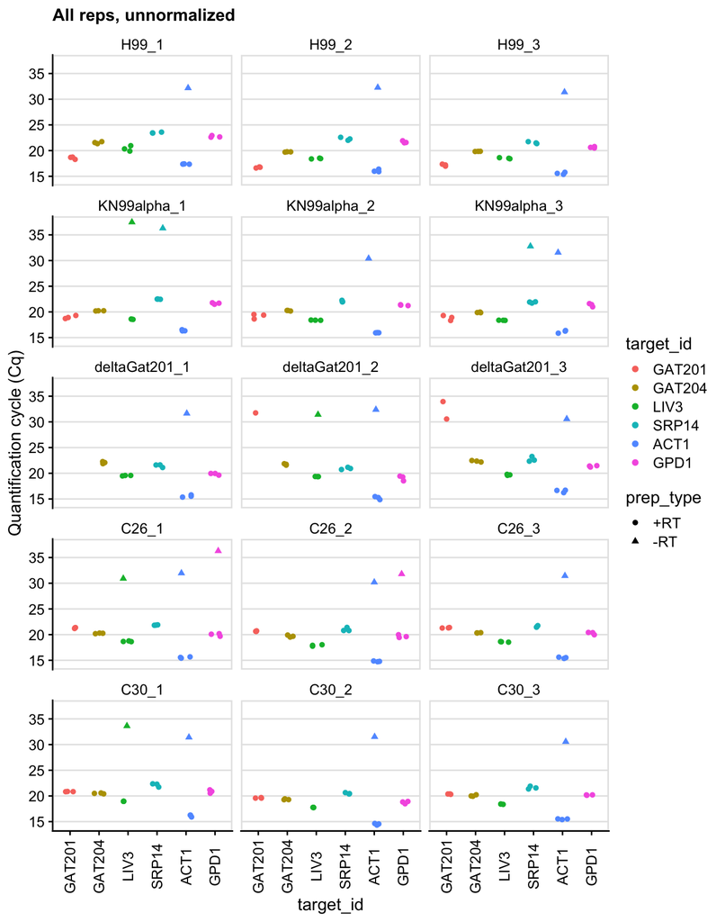

```r
ggplot(data = plate) +
  geom_point(aes(x = target_id, y = cq, shape = prep_type, colour = target_id),
    position = position_jitter(width = 0.2, height = 0)
  ) +
  labs(
    y = "Quantification cycle (Cq)",
    title = "All reps, unnormalized"
  ) +
  facet_wrap(~sample_id, ncol = 3) +
  theme(axis.text.x = element_text(angle = 90, vjust = 0.5))
```

The high or absent Cq values in -RT reactions indicate absence of DNA contamination.

# Check reference genes have consistent Cq across samples

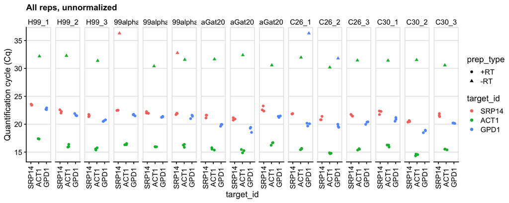

```r
ggplot(data = filter(plate, target_id == c("SRP14", "ACT1", "GPD1") )) +
  geom_point(aes(x = target_id, y = cq, shape = prep_type, colour = target_id),
    position = position_jitter(width = 0.2, height = 0)
  ) +
  labs(
    y = "Quantification cycle (Cq)",
    title = "All reps, unnormalized"
  ) +
  facet_grid(~sample_id) +
  theme(axis.text.x = element_text(angle = 90, vjust = 0.5))
```

These reference genes have consistent Cq across samples.

# Normalise data by calculating ∆Cq against median of 3 reference genes

```r
plate_norm <- plate %>%
  filter(prep_type == "+RT" )%>%
  calculate_deltacq_bysampleid(ref_target_ids = c("SRP14", "ACT1", "GPD1"))

plate_norm
```

```
## # A tibble: 270 × 22
##    Include Color Pos   Name         Cp Concentration Standard Status well     cq
##    <lgl>   <dbl> <chr> <chr>     <dbl> <lgl>            <dbl> <lgl>  <chr> <dbl>
##  1 TRUE      255 A1    Sample 1   18.7 NA                   0 NA     A1     18.7
##  2 TRUE      255 A2    Sample 2   21.6 NA                   0 NA     A2     21.6
##  3 TRUE      255 A3    Sample 3   19.9 NA                   0 NA     A3     19.9
##  4 TRUE      255 A4    Sample 4   23.4 NA                   0 NA     A4     23.4
##  5 TRUE      255 A5    Sample 5   17.4 NA                   0 NA     A5     17.4
##  6 TRUE      255 A6    Sample 6   22.6 NA                   0 NA     A6     22.6
##  7 TRUE      255 A7    Sample 7   18.3 NA                   0 NA     A7     18.3
##  8 TRUE      255 A8    Sample 8   21.7 NA                   0 NA     A8     21.7
##  9 TRUE      255 A9    Sample 9   20.3 NA                   0 NA     A9     20.3
## 10 TRUE      255 A10   Sample 10  23.4 NA                   0 NA     A10    23.4
## # … with 260 more rows, and 12 more variables: well_row <fct>, well_col <fct>,
## #   prep_type <fct>, tech_rep <fct>, target_id <fct>, sample_id <fct>,
## #   Strain <fct>, Strain_nice <fct>, BioRep <fct>, ref_cq <dbl>,
## #   delta_cq <dbl>, rel_abund <dbl>
```

```r
plate_norm_med <- plate_norm %>%
  group_by(sample_id, Strain, Strain_nice, BioRep, target_id) %>%
  summarize(
    delta_cq = median(delta_cq, na.rm = TRUE),
    rel_abund = median(rel_abund, na.rm = TRUE)
  )

plate_norm_med
```

```
## # A tibble: 90 × 7
## # Groups:   sample_id, Strain, Strain_nice, BioRep [15]
##    sample_id Strain Strain_nice BioRep target_id delta_cq rel_abund
##    <fct>     <fct>  <fct>       <fct>  <fct>        <dbl>     <dbl>
##  1 H99_1     H99    H99         1      GAT201      -3.98     15.8
##  2 H99_1     H99    H99         1      GAT204      -1.10      2.14
##  3 H99_1     H99    H99         1      LIV3        -2.33      5.03
##  4 H99_1     H99    H99         1      SRP14        0.780     0.582
##  5 H99_1     H99    H99         1      ACT1        -5.29     39.1
##  6 H99_1     H99    H99         1      GPD1         0         1
##  7 H99_2     H99    H99         2      GAT201      -4.83     28.4
##  8 H99_2     H99    H99         2      GAT204      -1.83      3.56
##  9 H99_2     H99    H99         2      LIV3        -3.14      8.82
## 10 H99_2     H99    H99         2      SRP14        0.690     0.620
## # … with 80 more rows
```

# Plot ∆Cq for normalized data

For all replicates of all genes, all samples.

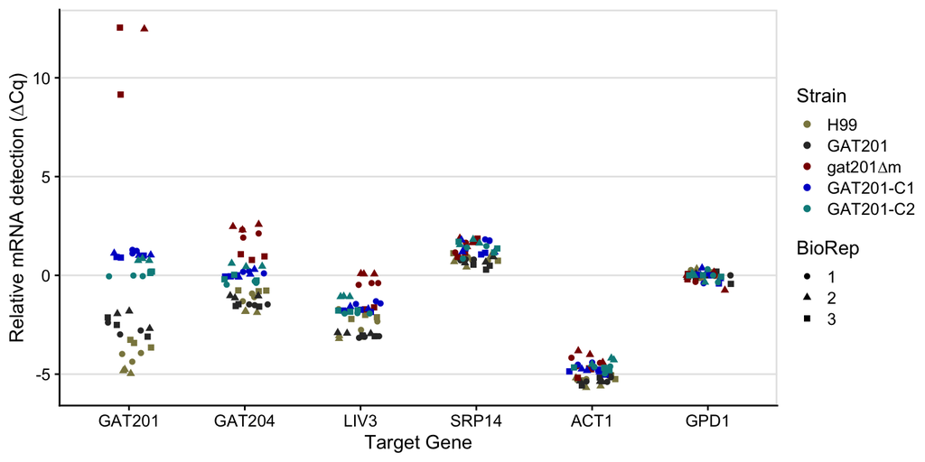

```r
ggplot(data = plate_norm) +
  geom_point(aes(x = target_id, y = delta_cq, shape = BioRep, colour = Strain_nice ),
    position = position_jitter(width = 0.2, height = 0)
  ) +

  labs(x = "Target Gene",
       y = "Relative mRNA detection (∆Cq)") +
    scale_color_strain
```

This again shows that reference genes have consistent ∆Cq across samples, while GAT201 targets differ.

```r
ggsave("../Results/deltacq_allreps.png", width = 7.5, height = 5)
```

# Normalise data by calculating ∆∆Cq against median of 3 reference samples (KN99alpha)

```r
plate_deltanorm <- plate_norm %>%
  calculate_deltadeltacq_bytargetid(ref_sample_ids = c("KN99alpha_1", "KN99alpha_2", "KN99alpha_3"))

plate_deltanorm_med <- plate_deltanorm %>%
    group_by(sample_id, target_id, Strain, Strain_nice, BioRep) %>%
  summarize(
    deltadelta_cq  = median(deltadelta_cq, na.rm = TRUE),
    fold_change    = median(fold_change,   na.rm = TRUE)
  )

plate_deltanorm
```

```
## # A tibble: 270 × 25
##    Include Color Pos   Name         Cp Concentration Standard Status well     cq
##    <lgl>   <dbl> <chr> <chr>     <dbl> <lgl>            <dbl> <lgl>  <chr> <dbl>
##  1 TRUE      255 A1    Sample 1   18.7 NA                   0 NA     A1     18.7
##  2 TRUE      255 A7    Sample 7   18.3 NA                   0 NA     A7     18.3
##  3 TRUE      255 A13   Sample 13  18.7 NA                   0 NA     A13    18.7
##  4 TRUE      255 B1    Sample 25  16.8 NA                   0 NA     B1     16.8
##  5 TRUE      255 B7    Sample 31  16.6 NA                   0 NA     B7     16.6
##  6 TRUE      255 B13   Sample 37  16.8 NA                   0 NA     B13    16.8
##  7 TRUE      255 C1    Sample 49  17.4 NA                   0 NA     C1     17.4
##  8 TRUE      255 C7    Sample 55  17.0 NA                   0 NA     C7     17.0
##  9 TRUE      255 C13   Sample 61  17.2 NA                   0 NA     C13    17.2
## 10 TRUE      255 D1    Sample 73  19.3 NA                   0 NA     D1     19.3
## # … with 260 more rows, and 15 more variables: well_row <fct>, well_col <fct>,
## #   prep_type <fct>, tech_rep <fct>, target_id <fct>, sample_id <fct>,
## #   Strain <fct>, Strain_nice <fct>, BioRep <fct>, ref_cq <dbl>,
## #   delta_cq <dbl>, rel_abund <dbl>, ref_delta_cq <dbl>, deltadelta_cq <dbl>,
## #   fold_change <dbl>
```

# Plot ∆∆Cq for normalized data

For all genes, all samples, summarized by biological replicate.

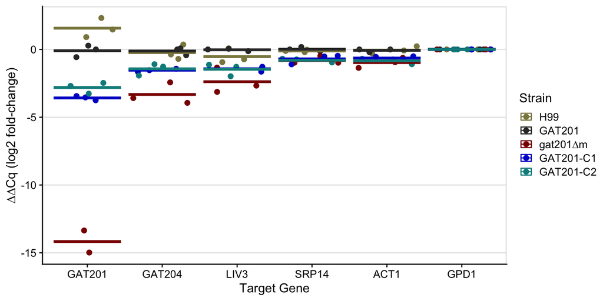

```r
set.seed(4)
ggplot(data = plate_deltanorm_med,
       aes(x = target_id, y = deltadelta_cq, colour = Strain_nice)
       ) +
  geom_point(
    position = position_jitter(width = 0.4, height = 0),
    size = 2
  ) +
  stat_summary(geom = "crossbar", fun.y = mean, fun.ymin = NULL, fun.ymax = NULL) +
  labs(x = "Target Gene",
       y = "∆∆Cq (log2 fold-change)") +
    scale_color_strain
```

# Plot ∆∆Cq for GAT201 targets only, summarized by biological replicate

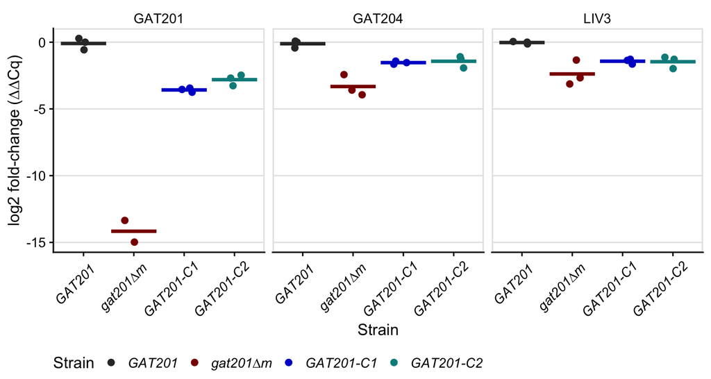

```r
set.seed(3)
plot_deltadelta_cq_facet <-
  ggplot(data = plate_deltanorm_med %>%
           dplyr::filter(
             target_id %in% c("GAT201", "GAT204", "LIV3"),
             Strain != c("H99")
           ),
         aes(x = Strain_nice, y = deltadelta_cq, colour = Strain_nice)
  ) +
  geom_point(
    position = position_jitter(width = 0.2, height = 0),
    size = 2
  ) +
  stat_summary(geom = "crossbar", fun.y = mean, fun.ymin = NULL, fun.ymax = NULL,
               key_glyph = "rect") +
  labs(x = "Strain",
       y = "log2 fold-change (∆∆Cq)") +
  facet_wrap(~target_id) +
  scale_color_strain +
  theme(legend.position = "bottom",
        axis.text.x = element_text(angle = 45, vjust = 0.8, hjust = 0.8, face = "italic"),
        legend.text = element_text(face = "italic"))
plot_deltadelta_cq_facet
```

```r
set.seed(3)
ggsave("../Results/GAT201targets_deltadeltacq.png", plot_deltadelta_cq_facet,
       width = 7.5, height = 3.5)
```

This summary figure is going in the Gat201 paper as:

> Figure S4, related to Figure 2: Partial complementation of Gat201 mRNA expression shown by RT-qPCR of GAT201, GAT204, and LIV3 genes compared to 3 reference genes (ACT1, GPD1, SRP14).

# Plot data only for Gat201

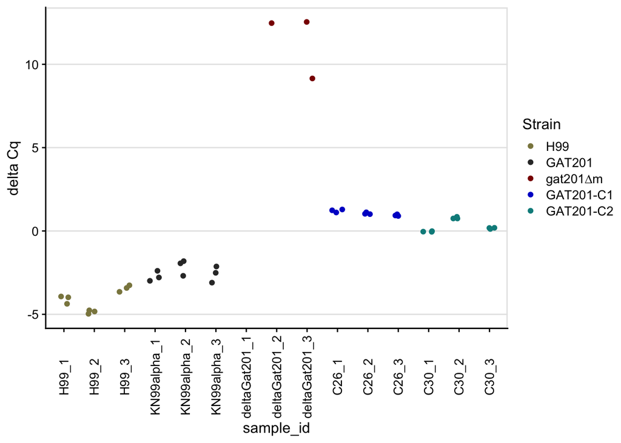

```r
ggplot(data = filter(plate_norm, target_id == c("GAT201") )) +
  geom_point(aes(x = sample_id, y = delta_cq, colour = Strain_nice),
    position = position_jitter(width = 0.2, height = 0)
  ) +
  labs(y = "delta Cq") +
  theme(axis.text.x = element_text(angle = 90, vjust = 0.5)) +
  scale_color_strain
```

```r
filter(plate_deltanorm_med, target_id == c("GAT201") )
```

```
## # A tibble: 15 × 7
## # Groups:   sample_id, target_id, Strain, Strain_nice [15]
##    sample_id     target_id Strain   Strain_nice BioRep deltadelta_cq fold_change
##    <fct>         <fct>     <fct>    <fct>       <fct>          <dbl>       <dbl>
##  1 H99_1         GAT201    H99      H99         1              1.47    2.77
##  2 H99_2         GAT201    H99      H99         2              2.32    4.99
##  3 H99_3         GAT201    H99      H99         3              0.910   1.88
##  4 KN99alpha_1   GAT201    KN99alp… GAT201      1              0.280   1.21
##  5 KN99alpha_2   GAT201    KN99alp… GAT201      2             -0.570   0.674
##  6 KN99alpha_3   GAT201    KN99alp… GAT201      3              0       1
##  7 deltaGat201_1 GAT201    deltaGa… gat201∆m    1             NA      NA
##  8 deltaGat201_2 GAT201    deltaGa… gat201∆m    2            -15.0     0.0000309
##  9 deltaGat201_3 GAT201    deltaGa… gat201∆m    3            -13.4     0.000169
## 10 C26_1         GAT201    C26      GAT201-C1   1             -3.75    0.0743
## 11 C26_2         GAT201    C26      GAT201-C1   2             -3.54    0.0860
## 12 C26_3         GAT201    C26      GAT201-C1   3             -3.44    0.0921
## 13 C30_1         GAT201    C30      GAT201-C2   1             -2.47    0.180
## 14 C30_2         GAT201    C30      GAT201-C2   2             -3.26    0.104
## 15 C30_3         GAT201    C30      GAT201-C2   3             -2.69    0.155
```

This emphasizes: there is about 10% of the mRNA abundance of GAT201 in the complemented strains, under these conditions.